# Crash course - Decoding Road accidents in the USA

Vedenikova Vitalia / Perez Olusese

2024-06-06

## Preface

As a foreword, please be aware that this work was made by a team of two people : Perez Olusese and Vitalia Vedenikova. Our team member Luis Marani quit the Master’s in Applied Information and Data Science and has therefore not worked with us on this project.

The context of this report is as follows: we are a team of data scientists mandated by the US Department of Transportation in 2023 to investigate car accidents in the USA for the year 2022.

## Introduction

In this report, we conduct a detailed statistical analysis of car accidents in the USA for the year 2022, focusing on the duration, frequency, and severity of accidents. By examining various variables, we aim to identify key predictors for the time it takes to resolve an accident, the occurrence of accidents, and their severity. Our findings reveal significant trends and correlations that can inform more effective road safety regulations and interventions. This analysis provides crucial insights that could help reduce the economic costs borne by taxpayers and enhance overall road safety.

We look forward to answering the following questions in our analysis.

- What variables are associated with longer times to resolve a car accident?
- What variables are associated with the occurrence an accident?
- What variables are the strongest predictors for the severity of an accident? Can it be accurately predicted?

## Description of the data used

Two primary datasets serve as the cornerstone for our analysis. The first data can be found on Kaggle through this link sethttps://www.kaggle.com/datasets/sobhanmoosavi/us-accidents. The author provided a sampled data set for easier handling which we will be using here.

Our second dataset is from US Census Bureau with estimated populations per city. (source: https://www.census.gov/data/tables/time-series/demo/popest/2020s-total-cities-and-towns.html): We included this data set because we would like to examine the population predictor in our models as well.

This paper does not contain the data transformation process as it is not the subject of our work.

It involved the following steps: 1. As a first step, we briefly examined the data set and filtered for the year 2022. 2. We removed unnecessary variables that were also full of NA values 3. We had to transform all units in the Imperial system of measurement to the metric system and rename some columns 4. We used stratified random sampling per US county to only keep 84% of the data and bring it below the size of N = 10^5 5. We categorized the streets into street types to be able to use them for our models 6. We calculated the duration of each accident, categorized the times of accidents into time intervals (morning, afternoon, etc.) and kept only the months of occurrence from the dates. 7. We dropped all irrelevant variables 8. We augmented our data frame with cities’ populations to take it into account during analysis 9. We handled missing data by replacing them by specifically defined means 10. We added the count of accidents per US state to be used in some models.

Full data preparation code can be read by pressing the button:

**Click here to see details**

```r
conflicts_prefer(lubridate::hour)
conflicts_prefer(lubridate::ymd)

############ 1. Load and read the data set. Only keep the data for the year 2022 ############

# Load and read the data
accident_raw <- read_csv("US_Accidents_March23_sampled_500k.csv")
str (accident_raw)
```

```
## spc_tbl_ [500,000 × 46] (S3: spec_tbl_df/tbl_df/tbl/data.frame)
##  $ ID                   : chr [1:500000] "A-2047758" "A-4694324" "A-5006183" "A-4237356" ...
##  $ Source               : chr [1:500000] "Source2" "Source1" "Source1" "Source1" ...
##  $ Severity             : num [1:500000] 2 2 2 2 2 2 2 2 2 2 ...
##  $ Start_Time           : POSIXct[1:500000], format: "2019-06-12 10:10:56" "2022-12-03 23:37:14" ...
##  $ End_Time             : POSIXct[1:500000], format: "2019-06-12 10:55:58" "2022-12-04 01:56:53" ...
##  $ Start_Lat            : num [1:500000] 30.6 39 34.7 43.7 35.4 ...
##  $ Start_Lng            : num [1:500000] -91.2 -77.4 -120.5 -93 -119 ...
##  $ End_Lat              : num [1:500000] NA 39 34.7 43.7 35.4 ...
##  $ End_Lng              : num [1:500000] NA -77.4 -120.5 -93 -119 ...
##  $ Distance(mi)         : num [1:500000] 0 0.056 0.022 1.054 0.046 ...
##  $ Description          : chr [1:500000] "Accident on LA-19 Baker-Zachary Hwy at Lower Zachary Rd." "Incident on FOREST RIDGE DR near PEPPERIDGE PL Drive with caution." "Accident on W Central Ave from Floradale Ave to Western Ave." "Incident on I-90 EB near REST AREA Drive with caution." ...
##  $ Street               : chr [1:500000] "Highway 19" "Forest Ridge Dr" "Floradale Ave" "14th St NW" ...
##  $ City                 : chr [1:500000] "Zachary" "Sterling" "Lompoc" "Austin" ...
##  $ County               : chr [1:500000] "East Baton Rouge" "Loudoun" "Santa Barbara" "Mower" ...
##  $ State                : chr [1:500000] "LA" "VA" "CA" "MN" ...
##  $ Zipcode              : chr [1:500000] "70791-4610" "20164-2813" "93436" "55912" ...
##  $ Country              : chr [1:500000] "US" "US" "US" "US" ...
##  $ Timezone             : chr [1:500000] "US/Central" "US/Eastern" "US/Pacific" "US/Central" ...
##  $ Airport_Code         : chr [1:500000] "KBTR" "KIAD" "KLPC" "KAUM" ...
##  $ Weather_Timestamp    : POSIXct[1:500000], format: "2019-06-12 09:53:00" "2022-12-03 23:52:00" ...
##  $ Temperature(F)       : num [1:500000] 77 45 68 27 42 42 35 90 91 63 ...
##  $ Wind_Chill(F)        : num [1:500000] 77 43 68 15 42 35 35 90 91 63 ...
##  $ Humidity(%)          : num [1:500000] 62 48 73 86 34 58 89 55 39 78 ...
##  $ Pressure(in)         : num [1:500000] 29.9 29.9 29.8 28.5 29.8 ...
##  $ Visibility(mi)       : num [1:500000] 10 10 10 10 10 10 10 10 10 10 ...
##  $ Wind_Direction       : chr [1:500000] "NW" "W" "W" "ENE" ...
##  $ Wind_Speed(mph)      : num [1:500000] 5 5 13 15 0 13 0 12 7 10 ...
##  $ Precipitation(in)    : num [1:500000] 0 0 0 0 0 0 0 0 0 0 ...
##  $ Weather_Condition    : chr [1:500000] "Fair" "Fair" "Fair" "Wintry Mix" ...
##  $ Amenity              : logi [1:500000] FALSE FALSE FALSE FALSE FALSE FALSE ...
##  $ Bump                 : logi [1:500000] FALSE FALSE FALSE FALSE FALSE FALSE ...
##  $ Crossing             : logi [1:500000] FALSE FALSE FALSE FALSE FALSE FALSE ...
##  $ Give_Way             : logi [1:500000] FALSE FALSE FALSE FALSE FALSE FALSE ...
##  $ Junction             : logi [1:500000] FALSE FALSE FALSE FALSE FALSE FALSE ...
##  $ No_Exit              : logi [1:500000] FALSE FALSE FALSE FALSE FALSE FALSE ...
##  $ Railway              : logi [1:500000] FALSE FALSE FALSE FALSE FALSE FALSE ...
##  $ Roundabout           : logi [1:500000] FALSE FALSE FALSE FALSE FALSE FALSE ...
##  $ Station              : logi [1:500000] FALSE FALSE FALSE FALSE FALSE FALSE ...
##  $ Stop                 : logi [1:500000] FALSE FALSE FALSE FALSE FALSE FALSE ...
```

[output cut: 42 more lines]

```
##   ..   Junction = col_logical(),
##   ..   No_Exit = col_logical(),
##   ..   Railway = col_logical(),
##   ..   Roundabout = col_logical(),
##   ..   Station = col_logical(),
##   ..   Stop = col_logical(),
##   ..   Traffic_Calming = col_logical(),
##   ..   Traffic_Signal = col_logical(),
##   ..   Turning_Loop = col_logical(),
##   ..   Sunrise_Sunset = col_character(),
##   ..   Civil_Twilight = col_character(),
##   ..   Nautical_Twilight = col_character(),
##   ..   Astronomical_Twilight = col_character()
##   .. )
##  - attr(*, "problems")=<externalptr>
```

```r
# create new variable year
accident_raw$year <-  (str_sub(accident_raw$Start_Time, 1, 4))

# filter only accidents in the year 2022
accident_2022 <- accident_raw %>% dplyr::filter(year == 2022)


############ 2. Removing Unnecessary variables ############

#lowercase names
names(accident_2022) <- tolower(names(accident_2022))

# Looking for variables which are NAs
colSums(is.na(accident_2022))
```

```
##                    id                source              severity
##                     0                     0                     0
##            start_time              end_time             start_lat
##                     0                     0                     0
##             start_lng               end_lat               end_lng
##                     0                 15384                 15384
##          distance(mi)           description                street
##                     0                     0                   470
##                  city                county                 state
##                     7                     0                     0
##               zipcode               country              timezone
##                    23                     0                   108
##          airport_code     weather_timestamp        temperature(f)
##                   460                  1866                  2477
##         wind_chill(f)           humidity(%)          pressure(in)
##                  3473                  2621                  2099
##        visibility(mi)        wind_direction       wind_speed(mph)
##                  2648                  3061                  3061
##     precipitation(in)     weather_condition               amenity
##                  4100                  2484                     0
##                  bump              crossing              give_way
##                     0                     0                     0
##              junction               no_exit               railway
##                     0                     0                     0
##            roundabout               station                  stop
##                     0                     0                     0
##       traffic_calming        traffic_signal          turning_loop
##                     0                     0                     0
##        sunrise_sunset        civil_twilight     nautical_twilight
##                   949                   949                   949
## astronomical_twilight                  year
##                   949                     0
```

```r
max(colSums(is.na(accident_2022)))
```

```
## [1] 15384
```

```r
accident_2022$precipitation.in. %in% c(NA, "NA")
```

```
## logical(0)
```

```r
sum(accident_2022$temperature.f. %in% c(NA, "NA"))
```

```
## [1] 0
```

```r
# end_lat, end_lng indicate the position where the accident ended. We consider them not relevant for our analysis and they have the max amount of missing values at 15384 each = these variables are eliminated
# until the variable weather_timestamp all values are available, from weather down seems to have some missing values

accident_2022_clean_01 <- subset(accident_2022, select = -c(end_lat, end_lng))
# new tibble [113,734 × 46]

############ 3. Fixing variable names and converting units to the metric system ############

#Fixing names
names(accident_2022_clean_01)
```

```
##  [1] "id"                    "source"                "severity"
##  [4] "start_time"            "end_time"              "start_lat"
##  [7] "start_lng"             "distance(mi)"          "description"
## [10] "street"                "city"                  "county"
## [13] "state"                 "zipcode"               "country"
## [16] "timezone"              "airport_code"          "weather_timestamp"
## [19] "temperature(f)"        "wind_chill(f)"         "humidity(%)"
## [22] "pressure(in)"          "visibility(mi)"        "wind_direction"
## [25] "wind_speed(mph)"       "precipitation(in)"     "weather_condition"
## [28] "amenity"               "bump"                  "crossing"
## [31] "give_way"              "junction"              "no_exit"
## [34] "railway"               "roundabout"            "station"
## [37] "stop"                  "traffic_calming"       "traffic_signal"
## [40] "turning_loop"          "sunrise_sunset"        "civil_twilight"
## [43] "nautical_twilight"     "astronomical_twilight" "year"
```

```r
accident_2022_clean_02 <- rename(accident_2022_clean_01,c(
  "lat_deg" = "start_lat",
  "lng_deg" = "start_lng",
  "dist_mi"="distance(mi)",
  "descript" = "description",
  "temp_f"  = "temperature(f)",
  "wind_chill_f" = "wind_chill(f)",
  "humid" = "humidity(%)",
  "press_in" = "pressure(in)",
  "visib_mi" = "visibility(mi)",
  "wind_speed_mph" = "wind_speed(mph)",
  "presip_in" = "precipitation(in)",
  "weather_cond" = "weather_condition",
  "nautic_twilight" = "nautical_twilight",
  "astron_twilight" = "astronomical_twilight"))


#Converting to the metric system
accident_2022_clean_03 <- accident_2022_clean_02 %>%
                          mutate(dist_km = dist_mi * 1.6093,
                                temp_c = (temp_f - 32) * 5 / 9,
                                wind_chill_c = (wind_chill_f - 32) * 5 / 9,
                                press_hpa = press_in * 1.33322,
                                visib_km = visib_mi * 1.6093,
                                wind_speed_kph = wind_speed_mph * 1.6093,
                                presip_mm = presip_in * 25.4)


#now removing the variables which are not in metric units and we drop all the 'twilight' variables since we already have the 'sunrise_sunset' variable telling us if it is day time or night time:
accident_2022_clean_03 <- accident_2022_clean_03 %>%
  select(-ends_with('_mi')) %>%    # drop any column with a name that ends with '_mi' for 'miles'
  select(-ends_with('_f')) %>%     # drop any column with a name that ends with '_f' for 'farenheit'
  select(-ends_with('_in')) %>%    # drop any column with a name that ends with '_in' for 'inches'
  select(-ends_with('_mph')) %>%    # drop any column with a name that ends with '_mph' for 'miles per hour'
  select(-(civil_twilight:astron_twilight)) # drop 'twilight' variables


############ 4. Reducing the size of the data frame with stratified sampling ############

# In order to keep the amount of data points below 10^5, we decided to reduce the amount of entries. The data set had 3 sources which were pulling information from the same places (US and state departments of transportation), we decided to randomly sample each county.

unique(accident_2022_clean_03$source)
```

```
## [1] "Source1" "Source2" "Source3"
```

```r
accident_2022_clean_04 <- accident_2022_clean_03%>%
  group_by(county) %>%
  sample_frac(size=.84) %>%
  ungroup()


accident_2022_clean_03 %>%
  group_by(state,county) %>%
  do(data.frame(nrow=nrow(.)))
```

```
## # A tibble: 1,972 × 3
## # Groups:   state, county [1,972]
##    state county    nrow
##    <chr> <chr>    <int>
##  1 AL    Autauga     15
##  2 AL    Baldwin     45
##  3 AL    Barbour      2
##  4 AL    Bibb         4
##  5 AL    Blount      33
##  6 AL    Butler       3
##  7 AL    Calhoun      7
##  8 AL    Chambers     2
##  9 AL    Cherokee     8
## 10 AL    Chilton     41
## # ℹ 1,962 more rows
```

```r
accident_2022_clean_04 %>%
  group_by(state,county) %>%
  do(data.frame(nrow=nrow(.)))
```

```
## # A tibble: 1,953 × 3
## # Groups:   state, county [1,953]
##    state county    nrow
##    <chr> <chr>    <int>
##  1 AL    Autauga     13
##  2 AL    Baldwin     38
##  3 AL    Barbour      2
##  4 AL    Bibb         2
##  5 AL    Blount      28
##  6 AL    Butler       3
##  7 AL    Calhoun      7
##  8 AL    Chambers     2
##  9 AL    Cherokee     8
## 10 AL    Chilton     34
## # ℹ 1,943 more rows
```

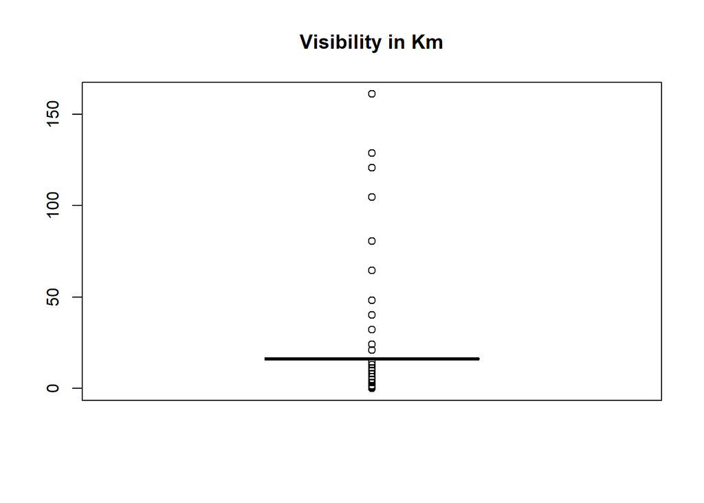

```r
############ 5. Creating a categorical variable for the streets ############

#We categorize the streets and make 'street' a categorical variable on this basis:

accident_2022_clean_05 <- accident_2022_clean_04 %>%
  mutate(street = case_when(
    grepl("\\bFwy\\b|\\bFWY\\b", street, ignore.case = TRUE) ~ "Freeway",
    grepl("\\bRd\\b|\\bRD\\b|\\bRoad\\b|\\bFL\\b|\\bFM\\b|\\bPl\\b|\\bPike\\b|\\bBdg\\b", street, ignore.case = TRUE) ~ "Road",
    grepl("\\bAve\\b|\\bAv\\b", street, ignore.case = TRUE) ~ "Avenue",
    grepl("\\bDr\\b|\\bdr\\b", street, ignore.case = TRUE) ~ "Drive",
    grepl("\\bPkwy\\b", street, ignore.case = TRUE) ~ "Parkway",
    grepl("\\bHwy\\b|\\bwy\\b", street, ignore.case = TRUE) ~ "Highway",
    grepl("\\bBlvd\\b|\\bblvd\\b", street, ignore.case = TRUE) ~ "Boulevard",
    grepl("\\bst\\b|\\bST\\b", street, ignore.case = TRUE) ~ "Street",
    grepl("\\bLn\\b|\\bln\\b", street, ignore.case = TRUE) ~ "Lane",
    grepl("\\bBrg\\b|\\bbrg\\b", street, ignore.case = TRUE) ~ "Bridge",
    grepl("\\bTpke\\b", street, ignore.case = TRUE) ~ "Turnpike",
    grepl("\\bRoute\\b|\\bEl\\ Camino\\b|\\bI-10\\b|\\bUS\\ 66\\b|\\bIL\\b|\\bIN\\b|\\bIA\\b|\\bUS\\b|\\bUT\\b", street, ignore.case = TRUE) ~ "Route",
    grepl("\\bTunl\\b|\\bTunnel\\b", street, ignore.case = TRUE) ~ "Tunnel",
    grepl("\\bTlwy\\b|\\bToll\\b", street, ignore.case = TRUE) ~ "Tollway",
    grepl("\\bWI\\b|\\bTX\\b", street, ignore.case = TRUE) ~ "State Highway",
    grepl("\\bBltwy\\b", street, ignore.case = TRUE) ~ "Beltway",
    grepl("\\bVA\\b|\\bW2100\\b|\\bW3300\\b|\\bExpy\\b", street, ignore.case = TRUE) ~ "Expressway",
    TRUE ~ "Others" # For any unmatched cases
  ))


############ 6. Handling the time variables ############

# We will add columns Hour and Month of the accident as well as time duration of the accident to our data set and remove "start_time" and "end_time" of the accidents:

accident_2022_clean_05$start_time<- ymd_hms(accident_2022_clean_05$start_time)
accident_2022_clean_05$end_time <- ymd_hms(accident_2022_clean_05$end_time)

accident_2022_clean_05 <- accident_2022_clean_05 %>%
  mutate(duration = as.numeric(difftime(end_time, start_time, units = "mins")))

accident_2022_clean_05$hour_accident <- as_hms(ymd_hms(accident_2022_clean_05$start_time))
accident_2022_clean_05$hour_accident <- hour(accident_2022_clean_05$hour_accident)

accident_2022_clean_05$date <- as.Date(accident_2022_clean_05$start_time)
accident_2022_clean_05$month <- lubridate::month(ymd(accident_2022_clean_05$date))

accident_2022_clean_05 <- accident_2022_clean_05 %>%
  select (-c(start_time))%>%
  select (-c(end_time)) %>%
  select (-c(date))

# We replace time with a categorical variable with levels by intervals of 6 hours: early morning (0h-6h), morning (6h-12h), afternoon (12h-18h), night(18h-0h).

accident_2022_clean_05$time_interval <- case_when(
  accident_2022_clean_05$hour_accident >= 0 & accident_2022_clean_05$hour_accident < 6 ~ "Early morning",
  accident_2022_clean_05$hour_accident >= 6 & accident_2022_clean_05$hour_accident < 12 ~ "Morning",
  accident_2022_clean_05$hour_accident >= 12 & accident_2022_clean_05$hour_accident < 18 ~ "Afternoon",
  TRUE ~ "Night"
)

accident_2022_clean_06 <- accident_2022_clean_05 %>%
  select (-c(hour_accident))



############ 7. Removing unnecessary variables ############

# We remove year, id, country, airport code, source of data, distance on which the accident took place, description of accidents, weather timestamp, lat_deg, ln_deg, zipcode. They are not relevant explanatory variables considering the focus of our work.

drop.col <- c("id", "source", "country", "airport_code","year", "descript", "weather_timestamp", "dist_km", "lat_deg", "lng_deg", "zipcode", "timezone")
accident_2022_clean_06 <- accident_2022_clean_06 %>%
  select (-one_of(drop.col))

#Here below, by looking at all the weather variables in a scatter plot, we can clearly see that there is a strong correlation between temperature and wind chill. Wind chill should be removed
#(note : we commented out the code since it takes some time to run).

#pairs( temp_c ~ wind_chill_c + presip_mm + humid + visib_km + wind_speed_kph + month, data = accident_2022_clean_06, upper.panel = panel.smooth)

# Some variables are removed in order to simplify our data set and future models. Since we already have the weather condition and the temperature, we decide to remove humidity, wind direction, press_hpa, wind_speed_kph as well as wind chill.

drop.col2 <- c("humid", "wind_direction", "press_hpa", "wind_chill_c", "wind_speed_kph")
accident_2022_clean_06 <- accident_2022_clean_06 %>%
  select (-one_of(drop.col2))

#The below boxplot also shows us that the visibility on the road is concentrated around the value of 16km, which is very good visibility. Also, visibility remains constant across the severity of the accidents as can be seen in the ggplot. We deduce that visibility is not correlated to car accidents and remove it from our data set.

boxplot(accident_2022_clean_06$visib_km, main="Visibility in Km")
```

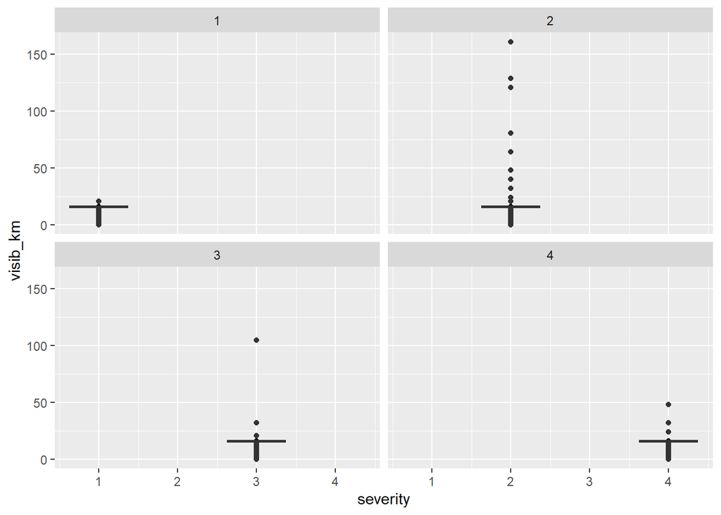

```r
ggplot(data = accident_2022_clean_06, mapping = aes(y = visib_km, x = severity)) + geom_point() + geom_boxplot() + facet_wrap(.~ severity)
```

```r
accident_2022_clean_06 <- accident_2022_clean_06 %>%
  select (-visib_km)

# We notice by looking at the boolean variables we have in our data set that there are quite a few that are 99%-100% false, therefore making them not interesting to model across states or road types. We decide to remove them for this reason.
summary(accident_2022_clean_06$traffic_calming) # ~0.1% are TRUE
```

```
##    Mode   FALSE    TRUE
## logical   95521      98
```

```r
summary(accident_2022_clean_06$roundabout)      # ~0% are TRUE
```

```
##    Mode   FALSE    TRUE
## logical   95615       4
```

```r
summary(accident_2022_clean_06$railway)         # ~0.1% are TRUE
```

```
##    Mode   FALSE    TRUE
## logical   94956     663
```

```r
summary(accident_2022_clean_06$turning_loop)    #  0% are TRUE
```

```
##    Mode   FALSE
## logical   95619
```

```r
summary(accident_2022_clean_06$give_way)        # ~0% are TRUE
```

```
##    Mode   FALSE    TRUE
## logical   95283     336
```

```r
summary(accident_2022_clean_06$bump)            # ~0% are TRUE
```

```
##    Mode   FALSE    TRUE
## logical   95573      46
```

```r
summary(accident_2022_clean_06$no_exit)         # ~0% are TRUE
```

```
##    Mode   FALSE    TRUE
## logical   95381     238
```

```r
drop.col3 <- c("traffic_calming", "roundabout", "railway", "turning_loop", "give_way", "bump", "no_exit")

accident_2022_clean_07 <- accident_2022_clean_06 %>%
  select (-one_of(drop.col3))

############ 8. Adding the population to our data set  ############

#We also consider at what level of granularity we want to examine our data. We can go down to individual streets in each US city, however we would instead prefer to consider ranges of populations per city. States are too large and counties largely vary in size depending on if we are on the West or East coast of the USA. For this reason, we would like to focus on cities and remove the "county" variable. Ultimately, we should also categorize cities' populations and examine the population predictor in our models as well.

## We import the populations data set from the US Census Bureau with estimated populations per city and reformat the table (source: https://www.census.gov/data/tables/time-series/demo/popest/2020s-total-cities-and-towns.html):

#d.population <- read_excel("D:/HSLU - Master's in Information and Data Science/Printemps 2024/Machine Learning 1/SUB-IP-EST2022-POP.xlsx")
d.population <- read_excel("SUB-IP-EST2022-POP.xlsx")
names(d.population) <- d.population[2,]
d.population <- d.population[-(1:2),]
names(d.population)[4] <- "2021"
names(d.population)[5] <- "2022"
d.population <- d.population[-c(2:4)]
d.population <- d.population[-1,]
d.population[c('city', 'state')] <- str_split_fixed(d.population$`Geographic Area`, ',', 2)
d.population <- d.population[c('state', 'city', '2022')]

d.population <- d.population %>%
  mutate(state = str_replace(state,'Alabama', 'AL'))%>%
  mutate(state = str_replace(state,'Alaska', 'AK'))%>%
  mutate(state = str_replace(state,'Arkansas', 'AR'))%>%
  mutate(state = str_replace(state,'Arizona', 'AZ'))%>%
  mutate(state = str_replace(state,'California', 'CA'))%>%
  mutate(state = str_replace(state,'Colorado', 'CO'))%>%
  mutate(state = str_replace(state,'Connecticut', 'CT'))%>%
  mutate(state = str_replace(state,'Delaware', 'DE'))%>%
  mutate(state = str_replace(state,'District of Columbia', 'DC'))%>%
  mutate(state = str_replace(state,'Florida', 'FL'))%>%
  mutate(state = str_replace(state,'Georgia', 'GA'))%>%
  mutate(state = str_replace(state,'Hawaii', 'HI'))%>%
  mutate(state = str_replace(state,'Idaho', 'ID'))%>%
  mutate(state = str_replace(state,'Illinois', 'IL'))%>%
  mutate(state = str_replace(state,'Indiana', 'IN'))%>%
  mutate(state = str_replace(state,'Iowa', 'IA'))%>%
  mutate(state = str_replace(state,'Kansas', 'KS'))%>%
  mutate(state = str_replace(state,'Kentucky', 'KY'))%>%
  mutate(state = str_replace(state,'Louisiana', 'LA'))%>%
  mutate(state = str_replace(state,'Maine', 'ME'))%>%
  mutate(state = str_replace(state,'Maryland', 'MD'))%>%
  mutate(state = str_replace(state,'Massachusetts', 'MA'))%>%
  mutate(state = str_replace(state,'Michigan', 'MI'))%>%
  mutate(state = str_replace(state,'Minnesota', 'MN'))%>%
  mutate(state = str_replace(state,'Mississippi', 'MS'))%>%
  mutate(state = str_replace(state,'Missouri', 'MO'))%>%
  mutate(state = str_replace(state,'Montana', 'MT'))%>%
  mutate(state = str_replace(state,'Nebraska', 'NE'))%>%
  mutate(state = str_replace(state,'Nevada', 'NV'))%>%
  mutate(state = str_replace(state,'New Hampshire', 'NH'))%>%
  mutate(state = str_replace(state,'New Jersey', 'NJ'))%>%
  mutate(state = str_replace(state,'New Mexico', 'NM'))%>%
  mutate(state = str_replace(state,'New York', 'NY'))%>%
  mutate(state = str_replace(state,'North Carolina', 'NC'))%>%
  mutate(state = str_replace(state,'North Dakota', 'ND'))%>%
  mutate(state = str_replace(state,'Ohio', 'OH'))%>%
  mutate(state = str_replace(state,'Oklahoma', 'OK'))%>%
  mutate(state = str_replace(state,'Oregon', 'OR'))%>%
  mutate(state = str_replace(state,'Pennsylvania', 'PA'))%>%
  mutate(state = str_replace(state,'Rhode Island', 'RI'))%>%
  mutate(state = str_replace(state,'South Carolina', 'SC'))%>%
  mutate(state = str_replace(state,'South Dakota', 'SD'))%>%
  mutate(state = str_replace(state,'Tennessee', 'TN'))%>%
  mutate(state = str_replace(state,'Texas', 'TX'))%>%
  mutate(state = str_replace(state,'Utah', 'UT'))%>%
  mutate(state = str_replace(state,'Vermont', 'VT'))%>%
  mutate(state = str_replace(state,'Virginia', 'VA'))%>%
  mutate(state = str_replace(state,'Washington', 'WA'))%>%
  mutate(state = str_replace(state,'West VA', 'WV'))%>%
  mutate(state = str_replace(state,'Wisconsin', 'WI'))%>%
  mutate(state = str_replace(state,'Wyoming', 'WY'))

##rename the 3rd column to population
colnames(d.population)[3] = 'cities_population'

##to insure a proper merge we keep only the city names in the population data frame:
d.population <- d.population %>%
  mutate(city = str_replace(city,'city', ''))%>%
  mutate(city = str_replace(city,'town', ''))

##change the type of the 3rd column to character so the data types of key columns match for the merge
d.population <- d.population %>%
  mutate(cities_population = trimws(as.character(cities_population)))
d.population <- as.data.frame(d.population)
accident_2022_clean_08 <- as.data.frame(accident_2022_clean_07 )

##remove unnecessary rows
d.population <- d.population[-(19494:19498),]

##Make sure that there are no white spaces in the columns we will use as keys for the merge
d.population <- d.population%>%
  mutate(cities_population = trimws(cities_population))%>%
  mutate(city= trimws(city))%>%
  mutate(state= trimws(state))

accident_2022_clean_08  <- accident_2022_clean_08 %>%
  mutate(city= trimws(city))%>%
  mutate(state= trimws(state))

## We augment our accidents data set with the population information by making a left join:
accident_2022_clean_08 <- left_join(accident_2022_clean_08 , d.population, by = c("state","city"))
head(accident_2022_clean_08)
```

```
##   severity street       city    county state weather_cond amenity crossing
## 1        2 Others  Abbeville Abbeville    SC         Fair   FALSE    FALSE
## 2        2 Others        Iva Abbeville    SC       Cloudy   FALSE    FALSE
## 3        2   Road    Donalds Abbeville    SC         Fair   FALSE    FALSE
## 4        1 Others Honea Path Abbeville    SC         Fair   FALSE    FALSE
## 5        2   Road        Iva Abbeville    SC      T-Storm   FALSE    FALSE
## 6        2 Others  Abbeville Abbeville    SC         Fair   FALSE    FALSE
##   junction station  stop traffic_signal sunrise_sunset    temp_c presip_mm
## 1    FALSE   FALSE FALSE          FALSE          Night 16.666667     0.000
## 2    FALSE   FALSE FALSE          FALSE          Night 10.000000     0.000
## 3    FALSE   FALSE  TRUE          FALSE            Day 31.666667     0.000
## 4    FALSE   FALSE FALSE          FALSE            Day 14.444444     0.000
## 5    FALSE   FALSE  TRUE          FALSE            Day 23.333333     1.778
## 6    FALSE   FALSE FALSE          FALSE          Night -2.777778     0.000
##   duration month time_interval cities_population
## 1 81.83333     4         Night              4859
## 2 79.11667    12       Morning              1158
## 3 79.00000     5     Afternoon               321
## 4 59.71667     5       Morning              3788
## 5 76.58333     7         Night              1158
## 6 28.85000     2 Early morning              4859
```

```r
############ 9. Handle missing values ############

#first, we make sure that there is NA in every empty row:
accident_2022_clean_09 <- accident_2022_clean_08
accident_2022_clean_09[accident_2022_clean_09 == ''] <- NA

#We inspect which variables have missing values and see that there are missing values in : cities_population, presip_mm, temp_c, weather_cond, sunrise_sunset, city
colSums(is.na(accident_2022_clean_09))
```

```
##          severity            street              city            county
##                 0                 0                 5                 0
##             state      weather_cond           amenity          crossing
##                 0              2097                 0                 0
##          junction           station              stop    traffic_signal
##                 0                 0                 0                 0
##    sunrise_sunset            temp_c         presip_mm          duration
##               806              2096              3461                32
##             month     time_interval cities_population
##                20                 0             24973
```

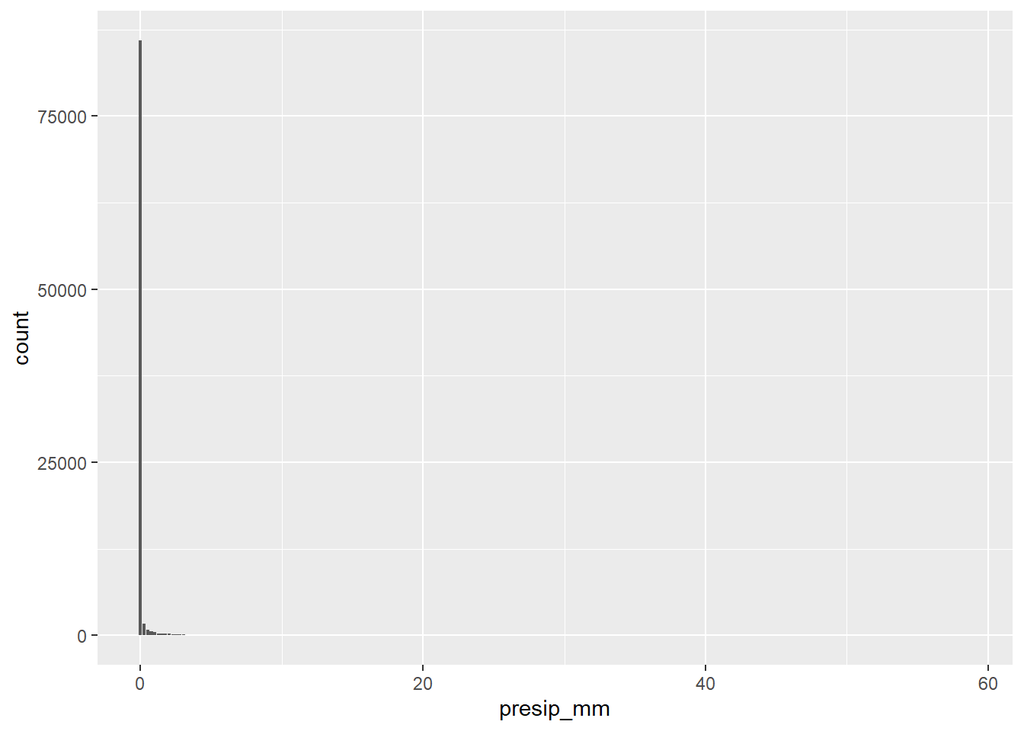

```r
#city: we take the most prevalent city for the relevant county and insert it in the empty rows. We also insert the relevant city's population.

occurences_per_city <- accident_2022_clean_09 %>%
  group_by(county, city)%>%
  summarize(n=n())%>%
  ungroup()

most_prevalent_city <- occurences_per_city %>%
  group_by(county)%>%
  slice(which.max(n))%>%
  ungroup()

colnames(most_prevalent_city)[2] = 'prevalent_city'

accident_2022_clean_09 <- left_join(accident_2022_clean_09 , most_prevalent_city, by = "county")

for (x in 1:nrow(accident_2022_clean_09)){
  if (is.na(accident_2022_clean_09$city[x])){
    accident_2022_clean_09$city[x] <- accident_2022_clean_09$prevalent_city[x]
    accident_2022_clean_09$cities_population[x]<-accident_2022_clean_09$cities_population[accident_2022_clean_09$city==accident_2022_clean_09$city[x]]
  }
}

accident_2022_clean_09 <- accident_2022_clean_09 %>%
  select (-prevalent_city)%>%
  select (-n)

#cities_population: 25% of cities' populations were not in the census survey. We remedy this by taking the mean of each county's cities' population and replacing it into the rows with NA for population.

accident_2022_clean_09$cities_population <- as.numeric(accident_2022_clean_09$cities_population)

accident_2022_clean_09 <- accident_2022_clean_09 %>%
  group_by(state, county) %>%
  mutate(cities_population = ifelse(is.na(cities_population), mean(cities_population, na.rm = TRUE),cities_population)) %>%
  ungroup()

#We take the population average on the county level otherwise for the 5520 still missing values
accident_2022_clean_09 <- accident_2022_clean_09 %>%
  group_by(state) %>%
  mutate(cities_population = ifelse(is.na(cities_population), mean(cities_population, na.rm = TRUE),cities_population)) %>%
  ungroup()


#We also see a lot of missing values for the temperature. We replace it with the mean temperature for the county in the relevant month when the accident took place.

accident_2022_clean_09 <- accident_2022_clean_09 %>%
  group_by(state, county, month) %>%
  mutate(temp_c = ifelse(is.na(temp_c), mean(temp_c, na.rm = TRUE), temp_c)) %>%
  ungroup()

#if there are still temperatures missing, then we take the mean temperature at state level:

accident_2022_clean_09 <- accident_2022_clean_09 %>%
  group_by(state, month) %>%
  mutate(temp_c = ifelse(is.na(temp_c), mean(temp_c, na.rm = TRUE), temp_c)) %>%
  ungroup()

#for this last missing temperature, we take the mean of the state
mean_temp_ME <- accident_2022_clean_09 %>%
  dplyr::filter(state == "ME") %>%
  summarize(mean_temperature = mean(temp_c, na.rm = TRUE))

accident_2022_clean_09$temp_c[84007] <- mean_temp_ME

#precipitation (mm): Most of the values are around 0, no matter the severity of the accident as shown by the bar graph and the boxplots below. We simply replace the NA with 0 and since it has a lot of outliers higher than 0, we keep it for now.
ggplot(accident_2022_clean_09, aes(x = presip_mm)) +
  geom_bar()
```

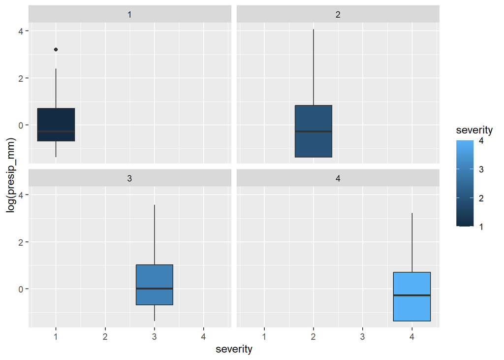

```r
ggplot(accident_2022_clean_09, aes(x=severity, y=log(presip_mm), fill=severity)) +
    geom_boxplot() +
    facet_wrap(~severity)
```

```r
accident_2022_clean_09["presip_mm"][is.na(accident_2022_clean_09["presip_mm"])]<-0

#sunrise_sunset: we define sunrise or sunset based on the time interval

day_or_night <- function(time_interval) {
  if (time_interval == "Morning"|time_interval == "Afternoon") {
    return("Day")
  } else {
    return("Night")
  }
}

accident_2022_clean_09$sunrise_sunset <- ifelse(is.na(accident_2022_clean_09$sunrise_sunset), sapply(accident_2022_clean_09$time_interval, day_or_night), accident_2022_clean_09$sunrise_sunset)


#weather_cond : we take the most prevalent weather condition in each city

highest_fequency_weather_city <- accident_2022_clean_09 %>%
  group_by(state, county, city, weather_cond) %>%
  summarize(n=n())%>%
  slice(which.max(n))%>%
  ungroup()

colnames(highest_fequency_weather_city)[4] = 'most_common_weather_city'

accident_2022_clean_09 <- left_join(accident_2022_clean_09 , highest_fequency_weather_city, by = c("state","county", "city"))

for (x in 1:nrow(accident_2022_clean_09)){
  if (is.na(accident_2022_clean_09$weather_cond[x])){
    accident_2022_clean_09$weather_cond[x] <- accident_2022_clean_09$most_common_weather_city[x]
  }
}

accident_2022_clean_09 <- accident_2022_clean_09 %>%
  select (-most_common_weather_city)%>%
  select (-n)

#if we are still missing weather conditions, we take the ones of the state
highest_fequency_weather_state <- accident_2022_clean_09 %>%
  group_by(state, weather_cond) %>%
  summarize(n=n())%>%
  slice(which.max(n))%>%
  ungroup()

colnames(highest_fequency_weather_state)[2] = 'most_common_weather_state'

accident_2022_clean_09 <- left_join(accident_2022_clean_09 , highest_fequency_weather_state, by = "state")

for (x in 1:nrow(accident_2022_clean_09)){
  if (is.na(accident_2022_clean_09$weather_cond[x])){
    accident_2022_clean_09$weather_cond[x] <- accident_2022_clean_09$most_common_weather_state[x]
  }
}

accident_2022_clean_09 <- accident_2022_clean_09 %>%
  select (-most_common_weather_state)%>%
  select (-n)

print(accident_2022_clean_09[accident_2022_clean_09$state =="SD",])
```

```
## # A tibble: 3 × 19
##   severity street city   county  state weather_cond amenity crossing junction
##      <dbl> <chr>  <chr>  <chr>   <chr> <chr>        <lgl>   <lgl>    <lgl>
## 1        4 Others Newell Butte   SD    Fair         FALSE   FALSE    FALSE
## 2        4 Others Reva   Harding SD    <NA>         FALSE   FALSE    FALSE
## 3        4 Others Reva   Harding SD    <NA>         FALSE   FALSE    FALSE
## # ℹ 10 more variables: station <lgl>, stop <lgl>, traffic_signal <lgl>,
## #   sunrise_sunset <chr>, temp_c <list>, presip_mm <dbl>, duration <dbl>,
## #   month <dbl>, time_interval <chr>, cities_population <dbl>
```

```r
accident_2022_clean_09$weather_cond[27426] <- "Fair" #we replace the missing values by "fair" since the dates of accidents at this location all match and the weather was recorded as fair for one of them.
accident_2022_clean_09$weather_cond[27427] <- "Fair"

colSums(is.na(accident_2022_clean_09))#we handled all the missing values that could be detected.
```

```
##          severity            street              city            county
##                 0                 0                 0                 0
##             state      weather_cond           amenity          crossing
##                 0                 0                 0                 0
##          junction           station              stop    traffic_signal
##                 0                 0                 0                 0
##    sunrise_sunset            temp_c         presip_mm          duration
##                 0                 1                 0                32
##             month     time_interval cities_population
##                20                 0                 0
```

```r
############ 10. Create the variable "accidents_count_per_state ############

#We count the number of accidents per each US state and create a new column.
accident_2022_clean_09$state <- as.factor(accident_2022_clean_09$state)
state_counts <- as.data.frame(table(accident_2022_clean_09$state))
names(state_counts) <- c("state", "accidents_count_per_state")
accident_2022_clean_09 <- merge(accident_2022_clean_09, state_counts, by = "state", all.x = TRUE)

accident_2022_clean_10 <- apply(accident_2022_clean_09,2,as.character)

#Finally, here we show how we saved the data in a csv file:
###############################################

#write.csv (accident_2022_clean_10, "../data/accident_22_clean_final.csv", row.names = TRUE)
#write.csv(accident_2022_clean_10, "D:/ML1_Project/data/accident_22_clean_final.csv", row.names = T)

#d.accidents <- read.csv("../data/accident_22_clean_final.csv", row.names = NULL)
#d.accidents <- read.csv("D:/ML1_Project/data/accident_22_clean_final.csv")

###############################################
```

The resulting data set for this report covers all 49 US States and its attributes can be described as follows:

**Data Summary**

[output not shown]

## Accident Duration

Car accidents involve a considerable amount of logistics: the appropriate amount of personnel and equipment has to be sent at the site of the crash, route deviations are organized and information has to be broadcast to drivers. Understanding what causes longer delays in resolving accidents is therefore crucial to ensure proper planning. For example, equipment could be made more readily available near certain locations at certain times, personnel shifts could be better planned and traffic surcharge in nearby locations could be avoided.

We will first proceed with a visual data analysis to determine which explanatory variables could be included in our Linear Model and the sort of interaction they could have with the duration of an accident.

## Linear Model

#### Vitalia Vedenikova took the lead on the Linear Model sectionn

### Exploratory visual analysis

In our data set, we notice that 74,4% of accidents get resolved in hours, while only 24.9% get resolved in minutes and a small percentage of 0.6% of accidents take several days to manage. To bring down the percentage of accidents resolved in hours, we want to first identify possible predictors by building a Correlation Matrix:

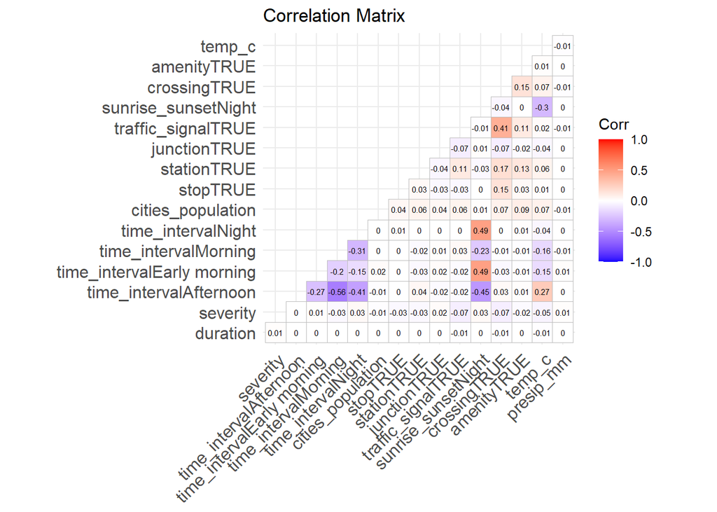

We would assume that an increase in population correlates to an increase in accident duration, but it does not appear to be the case as per the Correlation Matrix. The same can be said about the time intervals when accidents took place: they have no impact on duration. Lastly, temperatures did not seem to have an impact and neither did the precipitation level.

On the other hand, we can see that there is a possible weak negative correlation between duration and the presence of traffic signals and crossings. There might also be a positive correlation with severity. No obvious strong multicollinearity concerns can be observed.

### Duration and Severity

By fitting a bar plot showing the average duration per severity of accidents, we find that accidents with a long duration tend to have a severity of 4 out of 4 on average. In fact, some accidents of that severity took more than a day to resolve.

Examining the boxplots for each severity level with log transformed duration (due to the high quantity of outliers), the boxplot for severity 4 is higher than those of all other levels. This means that their duration tends to be higher. Their median is also higher, which is in line with what we evidenced with the barplot.

This is definitely a variable which we want to include in our Linear Model.

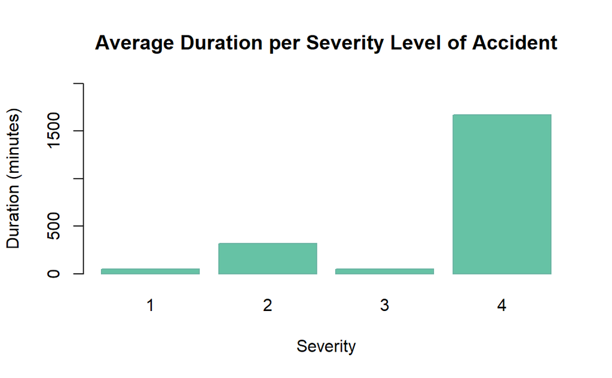

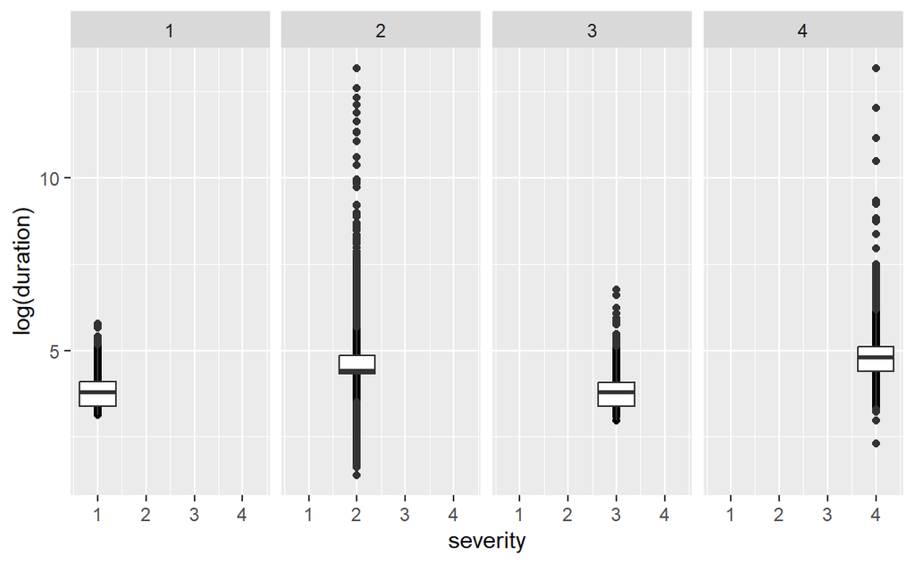

### Duration and the Locations of the Accidents

#### US States

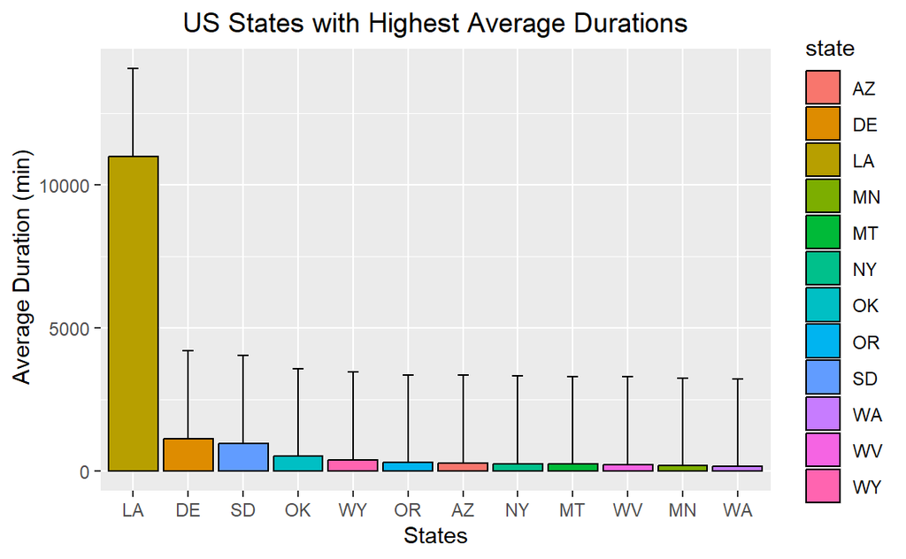

#### Street types

We notice that there appear to be some differences between the street types and notably that the median duration is highest for tunnels. This makes sense, since accidents in tunnels are more difficult to deal with due to increased danger.

While looking at barplots of counts of accidents for each street type, we also notice that there are more sever accidents happening on “Others”, “Roads” and “Routes”. Since we know that severity is correlated to duration, this is another contributing factor to our decision to keep streets as a possible predictor (perhaps to be used in an interaction term).

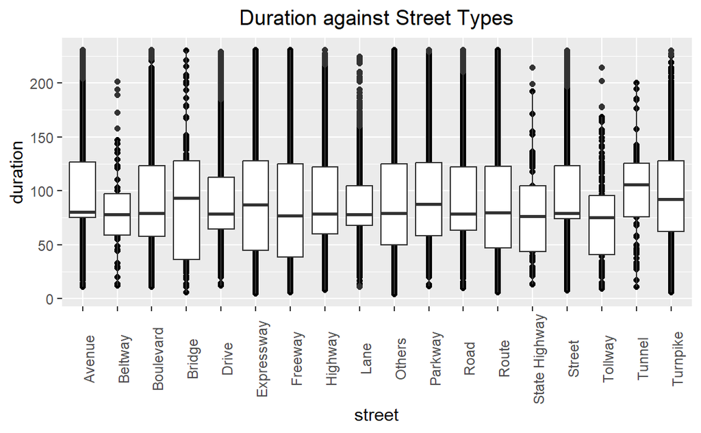

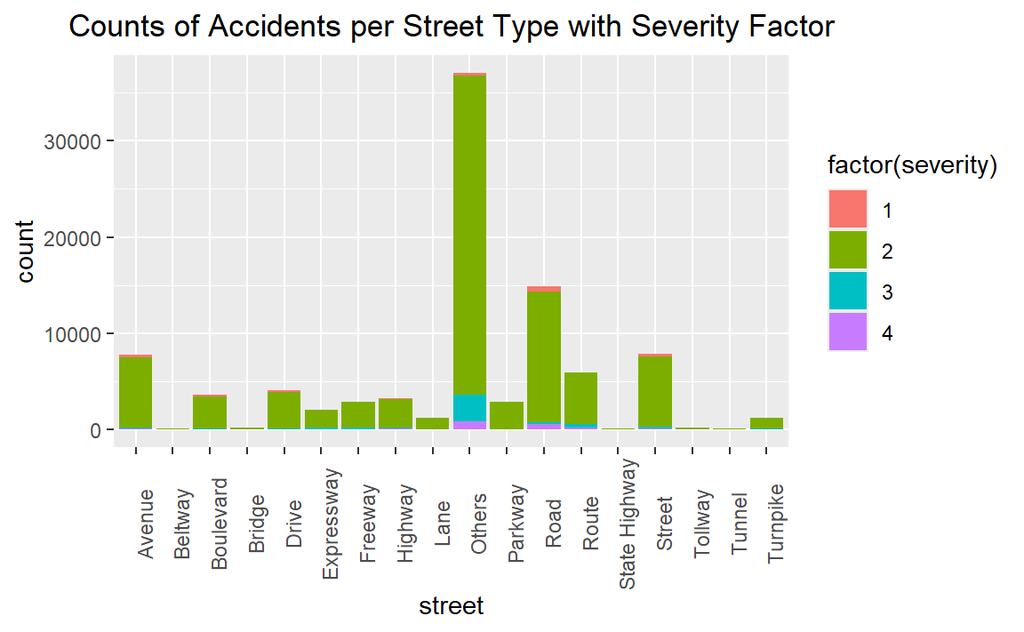

### When Accidents Took Place and Weather Conditions

Looking at boxplots for each month, we notice that the boxplots for the months of June, July and August are lower than most of the boxplots from other months. January through March are also somewhat lower which translates to shorter durations. This might be due to fairer weather, and indeed the longest durations appear to coincide with bad weather conditions: snow and wind or rain and wind. We therefore would like to use the months and the weather conditions as predictors in our models.

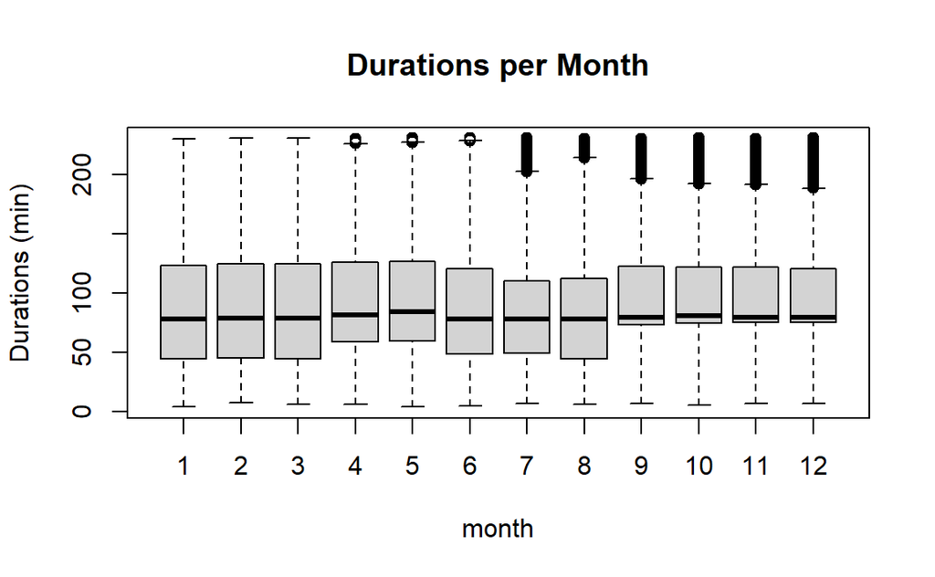

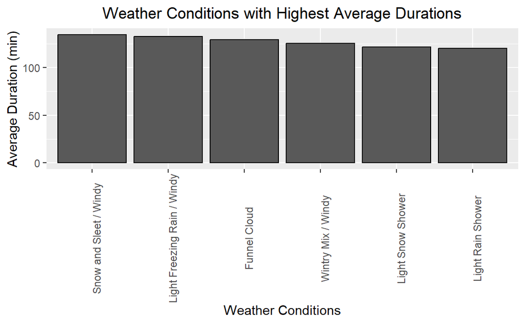

To conclude our exploratory analysis, we retain the following possible predictors for a linear model to explain the duration: severity, months, US States, street types and weather conditions.